# DACSS 603 Homework 3

Homework 3

Kirsten Johnson  
3/28/2022

### Question 1

###### (SMSS 11.2, except part (d))

##### For recent data in Jacksonville, Florida, on y = selling price of home (in dollars), x<sub>1</sub> = size of home (in square feet), and x<sub>2</sub> = lot size (in square feet), the prediction equation is ŷ = −10,536 + 53.8x<sub>1</sub> + 2.84x<sub>2</sub>.

##### A. A particular home of 1240 square feet on a lot of 18,000 square feet sold for $145,000. Find the predicted selling price and the residual, and interpret.

We are given a prediction equation ŷ = −10,536 + 53.8x<sub>1</sub> + 2.84x~2. I will plug in the given values for lot size and size of home to determine the predicted value for selling price.

```r
### Calculate and return predicted selling price
homesize1 = 1240
lotsize1 = 18000
price1 = -10536 + 53.8*homesize1 + 2.84*lotsize1
price1
```

```
[1] 107296
```

The predicted selling price is $107,296. Next I will subtract the predicted selling price from the observed selling price to obtain the residual.

```r
### Calculate and return residual
priceobserved = 145000
priceresidual = priceobserved - price1
priceresidual
```

```
[1] 37704
```

This residual means the house sold for $37,704 above what was predicted by the equation.

##### B. For fixed lot size, how much is the house selling price predicted to increase for each square-foot increase in home size? Why?

For fixed lot size, the house selling price is predicted to increase $53.80 for each square foot increase in home size. According to SSMS “In multiple regression, a slope describes the effect of an explanatory variable while controlling effects of the other explanatory variables in the model.” If lot size is fixed, we are controlling for it and therefore the slope of home size (53.80) is effecting the selling price.

##### C. According to this prediction equation, for fixed home size, how much would lot size need to increase to have the same impact as a one-square-foot increase in home size?

For 1 unit in lot size, house price increases by $2.84. For fixed home size, lot size would need to increase by 53.80/2.84 to have the same effect of 1 square foot increase in home size.

```r
### Calculate how much lot size would need to increase to have the same impact as a one-square-foot increase in home size
lotsize2 = 53.80/2.84
lotsize2
```

```
[1] 18.94366
```

Lot size would need to increase by $18.94 for have the same impact as a one-square-foot increase in home size.

### Question 2

###### (ALR, 5.17, slightly modified)

##### (Data file: salary in alr4 R package). The data file concerns salary and other characteristics of all faculty in a small Midwestern college collected in the early 1980s for presentation in legal proceedings for which discrimination against women in salary was at issue. All persons in the data hold tenured or tenure track positions; temporary faculty are not included. The variables include degree, a factor with levels PhD and MS; rank, a factor with levels Asst, Assoc, and Prof; sex, a factor with levels Male and Female; Year, years in current rank; ysdeg, years since highest degree, and salary, academic year salary in dollars.

##### A. Test the hypothesis that the mean salary for men and women is the same, without regard to any other variable but sex. Explain your findings.

As always, I will first import and preview the data.

```r
### Import data and preview
data("salary")
salarydata <- salary
head(salarydata)
```

```
   degree rank    sex year ysdeg salary
1 Masters Prof   Male   25    35  36350
2 Masters Prof   Male   13    22  35350
3 Masters Prof   Male   10    23  28200
4 Masters Prof Female    7    27  26775
5     PhD Prof   Male   19    30  33696
6 Masters Prof   Male   16    21  28516
```

Now I can conduct a hypothesis test. I will use a t.test function to test the null hypothesis that mean salary for men and women is the same.

```r
### Conduct two sample t-test
t.test(salary ~ sex, data = salarydata, var.equal = TRUE)
```

```
    Two Sample t-test

data:  salary by sex
t = 1.8474, df = 50, p-value = 0.0706
alternative hypothesis: true difference in means between group Male and group Female is not equal to 0
95 percent confidence interval:
 -291.257 6970.550
sample estimates:
  mean in group Male mean in group Female
            24696.79             21357.14
```

A p-value of 0.07 is returned for the t-test, meaning that if it were true that the difference in mean salary for men and women is equal to zero, the sample salaries could potentially be observed. Using a significance level of 5%, this means we fail to reject the null hypothesis despite there being a difference in the means.

##### B. Run a multiple linear regression with salary as the outcome variable and everything else as predictors, including sex. Assuming no interactions between sex and the other predictors, obtain a 95% confidence interval for the difference in salary between males and females.

I will use the lm function to run a multiple linear regression, then I will summarize it.

```r
#Run a multiple linear regression and summarize
salarylm<-lm(salary~degree+rank+sex+year+ysdeg, data = salary)
summary(salarylm)
```

```
Call:
lm(formula = salary ~ degree + rank + sex + year + ysdeg, data = salary)

Residuals:
    Min      1Q  Median      3Q     Max
-4045.2 -1094.7  -361.5   813.2  9193.1

Coefficients:
            Estimate Std. Error t value Pr(>|t|)
(Intercept) 15746.05     800.18  19.678  < 2e-16 ***
degreePhD    1388.61    1018.75   1.363    0.180
rankAssoc    5292.36    1145.40   4.621 3.22e-05 ***
rankProf    11118.76    1351.77   8.225 1.62e-10 ***
sexFemale    1166.37     925.57   1.260    0.214
year          476.31      94.91   5.018 8.65e-06 ***
ysdeg        -124.57      77.49  -1.608    0.115
---
Signif. codes:  0 '***' 0.001 '**' 0.01 '*' 0.05 '.' 0.1 ' ' 1

Residual standard error: 2398 on 45 degrees of freedom
Multiple R-squared:  0.855, Adjusted R-squared:  0.8357
F-statistic: 44.24 on 6 and 45 DF,  p-value: < 2.2e-16
```

I’ll use the confint function to construct a 95% confidence interval.

```r
confint(salarylm)
```

```
                 2.5 %      97.5 %
(Intercept) 14134.4059 17357.68946
degreePhD    -663.2482  3440.47485
rankAssoc    2985.4107  7599.31080
rankProf     8396.1546 13841.37340
sexFemale    -697.8183  3030.56452
year          285.1433   667.47476
ysdeg        -280.6397    31.49105
```

For the sexFemale variable, the confidence interval returned is -698 and 3031. This means that females make $698 less or $3031 more than males when taking other variables into account.

##### C. Interpret your finding for each predictor variable; discuss (a) statistical significance, (b) interpretation of the coefficient / slope in relation to the outcome variable and other variables.

The summary of the multiple linear regression is as follows:

```r
summary(salarylm)
```

```
Call:
lm(formula = salary ~ degree + rank + sex + year + ysdeg, data = salary)

Residuals:
    Min      1Q  Median      3Q     Max
-4045.2 -1094.7  -361.5   813.2  9193.1

Coefficients:
            Estimate Std. Error t value Pr(>|t|)
(Intercept) 15746.05     800.18  19.678  < 2e-16 ***
degreePhD    1388.61    1018.75   1.363    0.180
rankAssoc    5292.36    1145.40   4.621 3.22e-05 ***
rankProf    11118.76    1351.77   8.225 1.62e-10 ***
sexFemale    1166.37     925.57   1.260    0.214
year          476.31      94.91   5.018 8.65e-06 ***
ysdeg        -124.57      77.49  -1.608    0.115
---
Signif. codes:  0 '***' 0.001 '**' 0.01 '*' 0.05 '.' 0.1 ' ' 1

Residual standard error: 2398 on 45 degrees of freedom
Multiple R-squared:  0.855, Adjusted R-squared:  0.8357
F-statistic: 44.24 on 6 and 45 DF,  p-value: < 2.2e-16
```

##### D. Change the baseline category for the rank variable. Interpret the coefficients related to rank again.

I’ll use relevel() function to define the new reference category for rank as ’Prof”:

```r
## Create a new reference catagory for rank
salary$rank <- relevel(salary$rank, ref = 'Prof')
summary(lm(salary ~ ., data = salary))
```

```
Call:
lm(formula = salary ~ ., data = salary)

Residuals:
    Min      1Q  Median      3Q     Max
-4045.2 -1094.7  -361.5   813.2  9193.1

Coefficients:
             Estimate Std. Error t value Pr(>|t|)
(Intercept)  26864.81    1375.29  19.534  < 2e-16 ***
degreePhD     1388.61    1018.75   1.363    0.180
rankAsst    -11118.76    1351.77  -8.225 1.62e-10 ***
rankAssoc    -5826.40    1012.93  -5.752 7.28e-07 ***
sexFemale     1166.37     925.57   1.260    0.214
year           476.31      94.91   5.018 8.65e-06 ***
ysdeg         -124.57      77.49  -1.608    0.115
---
Signif. codes:  0 '***' 0.001 '**' 0.01 '*' 0.05 '.' 0.1 ' ' 1

Residual standard error: 2398 on 45 degrees of freedom
Multiple R-squared:  0.855, Adjusted R-squared:  0.8357
F-statistic: 44.24 on 6 and 45 DF,  p-value: < 2.2e-16
```

By changing the baseline to professor, the coeffiecient of rankAsst means that assistant professors will make $11119 less than professor. The rankAssoc coefficient means that associate professors will make $5826 less than professors.

##### E. Finkelstein (1980), in a discussion of the use of regression in discrimination cases, wrote, “[a] variable may reflect a position or status bestowed by the employer, in which case if there is discrimination in the award of the position or status, the variable may be ‘tainted.’” Thus, for example, if discrimination is at work in promotion of faculty to higher ranks, using rank to adjust salaries before comparing the sexes may not be acceptable to the courts. Exclude the variable rank, refit, and summarize how your findings changed, if they did.

Finkelstein brings up a great point! Let’s try excluding rank and see if things change:

```r
## Run regression but exclude rank
summary(lm(salary ~ . - rank, data = salary))
```

```
Call:
lm(formula = salary ~ . - rank, data = salary)

Residuals:
    Min      1Q  Median      3Q     Max
-8146.9 -2186.9  -491.5  2279.1 11186.6

Coefficients:
            Estimate Std. Error t value Pr(>|t|)
(Intercept) 17183.57    1147.94  14.969  < 2e-16 ***
degreePhD   -3299.35    1302.52  -2.533 0.014704 *
sexFemale   -1286.54    1313.09  -0.980 0.332209
year          351.97     142.48   2.470 0.017185 *
ysdeg         339.40      80.62   4.210 0.000114 ***
---
Signif. codes:  0 '***' 0.001 '**' 0.01 '*' 0.05 '.' 0.1 ' ' 1

Residual standard error: 3744 on 47 degrees of freedom
Multiple R-squared:  0.6312,    Adjusted R-squared:  0.5998
F-statistic: 20.11 on 4 and 47 DF,  p-value: 1.048e-09
```

##### F. Everyone in this dataset was hired the year they earned their highest degree. It is also known that a new Dean was appointed 15 years ago, and everyone in the dataset who earned their highest degree 15 years ago or less than that has been hired by the new Dean. Some people have argued that the new Dean has been making offers that are a lot more generous to newly hired faculty than the previous one and that this might explain some of the variation in Salary. Create a new variable that would allow you to test this hypothesis and run another multiple regression model to test this. Select variables carefully to make sure there is no multicollinearity. Explain why multicollinearity would be a concern in this case and how you avoided it. Do you find support for the hypothesis that the people hired by the new Dean are making higher than those that were not?

I can create a dummy variable “newdean” for people who were hired by the new dean vs the old dean using the years since people earned their highest degree (ysdeg). I’ll use mutate to do this and I will preview the data to make sure I computed correctly.

```r
### Create new variable 'newdean' based on ysdeg and preview.
salarydata<- salarydata%>%
  mutate(newdean = ifelse(ysdeg<=15, 1, 0))
head(salarydata,30)
```

```
    degree  rank    sex year ysdeg salary newdean
1  Masters  Prof   Male   25    35  36350       0
2  Masters  Prof   Male   13    22  35350       0
3  Masters  Prof   Male   10    23  28200       0
4  Masters  Prof Female    7    27  26775       0
5      PhD  Prof   Male   19    30  33696       0
6  Masters  Prof   Male   16    21  28516       0
7      PhD  Prof Female    0    32  24900       0
8  Masters  Prof   Male   16    18  31909       0
9      PhD  Prof   Male   13    30  31850       0
10     PhD  Prof   Male   13    31  32850       0
11 Masters  Prof   Male   12    22  27025       0
12 Masters Assoc   Male   15    19  24750       0
13 Masters  Prof   Male    9    17  28200       0
14     PhD Assoc   Male    9    27  23712       0
```

[output cut: 16 more lines]

The new variable looks good, those hired under the old dean have a value of 0 and those hired under the new dean have a value of 1. Now we can re run the model, but we need to consider multicollinearity. Multicollinearity is where independent variables in a model are highly correlated. This is especially concern in this case since we are trying to determine if certain variables in our model speak to any potential discrimination happening. If we include variables that are correlated, this can statistically skew our results, making it more difficult to determine what is contributing to discrimination. Since the new variable dean was created from ysdeg, they will likely be correlated. But we can check it with a quick regression test.

```r
### Conduct regression test for ysdeg vs dean
cor.test((salarydata$ysdeg), (salarydata$newdean))
```

```
    Pearson's product-moment correlation

data:  (salarydata$ysdeg) and (salarydata$newdean)
t = -11.101, df = 50, p-value = 4.263e-15
alternative hypothesis: true correlation is not equal to 0
95 percent confidence interval:
 -0.9074548 -0.7411040
sample estimates:
       cor
-0.8434239
```

We have a small p-value, making the correlation statistically significant between the two variables. We can re run the regression and exclude ysdeg.

```r
### Run multiple linear regression, exclude ysdeg
summary(lm(salary ~ . -ysdeg, data = salarydata))
```

```
Call:
lm(formula = salary ~ . - ysdeg, data = salarydata)

Residuals:
    Min      1Q  Median      3Q     Max
-3403.3 -1387.0  -167.0   528.2  9233.8

Coefficients:
            Estimate Std. Error t value Pr(>|t|)
(Intercept) 13328.38    1483.38   8.985 1.33e-11 ***
degreePhD     818.93     797.48   1.027   0.3100
rankAssoc    4972.66     997.17   4.987 9.61e-06 ***
rankProf    11096.95    1191.00   9.317 4.54e-12 ***
sexFemale     907.14     840.54   1.079   0.2862
year          434.85      78.89   5.512 1.65e-06 ***
newdean      2163.46    1072.04   2.018   0.0496 *
---
Signif. codes:  0 '***' 0.001 '**' 0.01 '*' 0.05 '.' 0.1 ' ' 1

Residual standard error: 2362 on 45 degrees of freedom
Multiple R-squared:  0.8594,    Adjusted R-squared:  0.8407
F-statistic: 45.86 on 6 and 45 DF,  p-value: < 2.2e-16
```

The new model suggest that those hired under the new dean make $2163 more than those hired under the old dean. The new dean variable is also statistically significant, as it has a p-value of 0.049. This mean that there is support for the hypothesis that the people hired by the new Dean are making higher than those that were not. However, I should note that this p-value is extremely close to our usual significance cut-off of 5%.

### Question 3

###### (SMSS 13.7 & 13.8 combined, modified)

###### (Data file: house.selling.price in smss R package)

##### A. Using the house.selling.price data, run and report regression results modeling y = selling price (in dollars) in terms of size of home (in square feet) and whether the home is new (1 = yes; 0 = no). In particular, for each variable; discuss statistical significance and interpret the meaning of the coefficient.

Let’s import and preview our data.

```r
###Import and preview data
data("house.selling.price")
hsp<- house.selling.price
head(hsp)
```

```
  case Taxes Beds Baths New  Price Size
1    1  3104    4     2   0 279900 2048
2    2  1173    2     1   0 146500  912
3    3  3076    4     2   0 237700 1654
4    4  1608    3     2   0 200000 2068
5    5  1454    3     3   0 159900 1477
6    6  2997    3     2   1 499900 3153
```

I will use the lm function run a multiple linear regression where price is the dependent variable and size and new are the independent variables.

```r
###Run multiple linear regression and summarize.
summary(lm(Price~ Size + New, data=hsp))
```

```
Call:
lm(formula = Price ~ Size + New, data = hsp)

Residuals:
    Min      1Q  Median      3Q     Max
-205102  -34374   -5778   18929  163866

Coefficients:
              Estimate Std. Error t value Pr(>|t|)
(Intercept) -40230.867  14696.140  -2.738  0.00737 **
Size           116.132      8.795  13.204  < 2e-16 ***
New          57736.283  18653.041   3.095  0.00257 **
---
Signif. codes:  0 '***' 0.001 '**' 0.01 '*' 0.05 '.' 0.1 ' ' 1

Residual standard error: 53880 on 97 degrees of freedom
Multiple R-squared:  0.7226,    Adjusted R-squared:  0.7169
F-statistic: 126.3 on 2 and 97 DF,  p-value: < 2.2e-16
```

The coefficients returned for each variable show us that with an increase in size, the selling price increases by $116, and if a home is new, the selling price increases by $57,736. Both of these variables are statistically significant.

##### B. Report and interpret the prediction equation, and form separate equations relating selling price to size for new and for not new homes.

The prediction equation for this model is:

##### E[selling price]=−40230.867+116.132∗size+57736.283∗new

The variable “new” is a dummy, meaning it has two possible values: 1 if new or 0 if old. Therefore, the prediction equation for the selling price based on it being new and it’s size would be:

##### E(Selling Price) = -40230.867 + size*116.132 + 57736.283*1

The prediction equation for the selling price based on it being old and it’s size would be:

##### E(Selling Price) = -40230.867 + size*116.132 + 57736.283*0

##### C. Find the predicted selling price for a home of 3000 square feet that is (i) new, (ii) not new.

Using our equations from part B, we can calculate the price of this home:

```r
### Find price of 3000 sq foot home
size=3000
new=1
old=0
b0=-40230.867
b1=116.132
b2=57736.283

pricenew<- b0+b1*size+b2*new
pricenold<- b0+b1*size+b2*old
pricenew
```

```
[1] 365901.4
```

```r
pricenold
```

```
[1] 308165.1
```

The selling price for a new home that is 3000 square feet is $365,901.40. The selling price for a old home that is 3000 square feet is $308,165.10.

##### D. Fit another model, this time with an interaction term allowing interaction between size and new, and report the regression results

I’ll add an interaction term size*new into our model:

```r
###Run multiple linear regression with interaction term size*new and summarize.
summary(lm(Price~ Size + New + Size*New, data=hsp))
```

```
Call:
lm(formula = Price ~ Size + New + Size * New, data = hsp)

Residuals:
    Min      1Q  Median      3Q     Max
-175748  -28979   -6260   14693  192519

Coefficients:
              Estimate Std. Error t value Pr(>|t|)
(Intercept) -22227.808  15521.110  -1.432  0.15536
Size           104.438      9.424  11.082  < 2e-16 ***
New         -78527.502  51007.642  -1.540  0.12697
Size:New        61.916     21.686   2.855  0.00527 **
---
Signif. codes:  0 '***' 0.001 '**' 0.01 '*' 0.05 '.' 0.1 ' ' 1

Residual standard error: 52000 on 96 degrees of freedom
Multiple R-squared:  0.7443,    Adjusted R-squared:  0.7363
F-statistic: 93.15 on 3 and 96 DF,  p-value: < 2.2e-16
```

The interaction between the variables size and new has a p value of 0.005, making the interaction statistically significant.

##### E. Report the lines relating the predicted selling price to the size for homes that are (i) new, (ii) not new.

The prediction equation for this new model that includes the interaction term is:

##### E[selling price]=-22227.808+104.438∗size+-78527.502∗new+new* 61.916*size

The prediction equation for the selling price based on it being new is:

##### E[selling price]=-22227.808+104.438∗size+-78527.502∗1+ 1* 61.916*size

The prediction equation for the selling price based on it being old is:

##### E[selling price]=-22227.808+104.438∗size+-78527.502∗0+0* 61.916*size

I can plot the lines as follows:

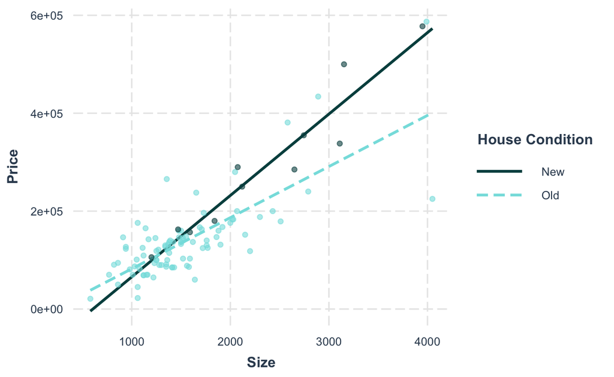

```r
library(interactions)
###plot lines
hsp_int= lm(Price~ Size + New + Size*New, data=hsp)

interact_plot(hsp_int, pred = Size, modx = New, data=hsp, plot.points = TRUE, jitter = 0.1, point.shape = TRUE, legend.main = "House Condition", modx.labels = c("Old", "New"), colors = "seagreen")
```

The plot clearly shows the interaction between size and the house being new. As size increases, the selling price of the house increases more rapidly with size if the house is new vs if the house is not new.

##### F. Find the predicted selling price for a home of 3000 square feet that is (i) new, (ii) not new.

```r
###Find price of 3000 ft house using model with interaction term

intb0=-22227.808
intb1=104.438
intb2=-78527.502
intb3<-61.916
pricenewint<- intb0+intb1*size+intb2*new+size*new*intb3
pricenoldint<- intb0+intb1*size+intb2*old+size*old*intb3
pricenewint
```

```
[1] 398306.7
```

```r
pricenoldint
```

```
[1] 291086.2
```

With the added interaction term, the estimated selling price of a 3000 sq ft house is $398306.70 when it is new and $291086.20 when it is old.

##### G. Find the predicted selling price for a home of 1500 square feet that is (i) new, (ii) not new. Comparing to (F), explain how the difference in predicted selling prices changes as the size of home increases.

```r
###Find price of 1500 sq ft house using model with interaction term
size2 = 1500
intb0=-22227.808
intb1=104.438
intb2=-78527.502
intb3<-61.916
pricenewint<- intb0+intb1*size2+intb2*new+size2*new*intb3
pricenoldint<- intb0+intb1*size2+intb2*old+size2*old*intb3
pricenewint
```

```
[1] 148775.7
```

```r
pricenoldint
```

```
[1] 134429.2
```

With the interaction term, the estimated selling price of a 1500 sq ft house is $148775.70 when it is new and $134429.20 when it is old.

The difference in price between a new vs old house for the 3000 sq foot home is $107220.50. For a 1500 sq ft home, the difference is $14346.50. When you double the size of the house, the difference in price between the old and new houses is 7 times greater in the larger size. The price slope is greater for newer houses than older houses.

##### H. Do you think the model with interaction or the one without it represents the relationship of size and new to the outcome price? What makes you prefer one model over another?

Going back to the models, we can compare their R^2 to see which is a better fit.

```r
### Compare models with and without interaction term.
summary(lm(Price~ Size + New, data=hsp))
```

```
Call:
lm(formula = Price ~ Size + New, data = hsp)

Residuals:
    Min      1Q  Median      3Q     Max
-205102  -34374   -5778   18929  163866

Coefficients:
              Estimate Std. Error t value Pr(>|t|)
(Intercept) -40230.867  14696.140  -2.738  0.00737 **
Size           116.132      8.795  13.204  < 2e-16 ***
New          57736.283  18653.041   3.095  0.00257 **
---
Signif. codes:  0 '***' 0.001 '**' 0.01 '*' 0.05 '.' 0.1 ' ' 1

Residual standard error: 53880 on 97 degrees of freedom
Multiple R-squared:  0.7226,    Adjusted R-squared:  0.7169
F-statistic: 126.3 on 2 and 97 DF,  p-value: < 2.2e-16
```

```r
summary(hsp_int)
```

```
Call:
lm(formula = Price ~ Size + New + Size * New, data = hsp)

Residuals:
    Min      1Q  Median      3Q     Max
-175748  -28979   -6260   14693  192519

Coefficients:
              Estimate Std. Error t value Pr(>|t|)
(Intercept) -22227.808  15521.110  -1.432  0.15536
Size           104.438      9.424  11.082  < 2e-16 ***
New         -78527.502  51007.642  -1.540  0.12697
Size:New        61.916     21.686   2.855  0.00527 **
---
Signif. codes:  0 '***' 0.001 '**' 0.01 '*' 0.05 '.' 0.1 ' ' 1

Residual standard error: 52000 on 96 degrees of freedom
Multiple R-squared:  0.7443,    Adjusted R-squared:  0.7363
F-statistic: 93.15 on 3 and 96 DF,  p-value: < 2.2e-16
```

The r-squared tells us the proportion of variation in our dependent variable explained by the independent variable. The adjusted r-squared adjusts the statistic based on the number of independent variables in the model. Both the regular and the adjusted r-squared for the second model are greater than the first model. Given this and that the interaction term is statistically significant, I’m inclined to say that the second model with the interactionn term is a better fit.